# Zad1_Model_Altmana

- Show All Code
- Hide All Code
- View Source

Author

Mikołaj Ziółkowski, Tomasz Sałapatek

Published

May 4, 2025

# 1 Teoria:

## 1.1 Czym jest ryzyko kredytowe?

Ryzyko kredytowe to rodzaj ryzyka finansowego, które odnosi się do możliwości niewywiązania się jednej ze stron z warunków umowy kredytowej. Dotyczy ono m.in. wiarygodności kredytowej oraz potencjalnego naruszenia warunków spłaty, a jego wpływ można mierzyć za pomocą różnych modeli, takich jak modele empiryczne, strukturalne czy zredukowane.

## 1.2 Idea liniowej analizy dyskryminacyjnej. Dlaczego można ją wykorzystać do analizy ryzyka kredytowego?

Liniowa analiza dyskryminacyjna jest użyteczna w ocenie ryzyka kredytowego, ponieważ pozwala na klasyfikację klientów na podstawie ich cech, takich jak dochody czy historia kredytowa. Stara się maksymalizować różnice między grupami, co pomaga w lepszym rozdzieleniu klientów o różnym ryzyku. Dane często przyjmują rozkład normalny co pomaga LDA, bo to jest zakładane przy jej przeprowadzaniu.

## 1.3 Jaką ma postać, do czego służy i jakie ograniczenia ma model Altmana?

**Zmienne:**  
• X1 aktywa obrotowe / aktywa ogółem  
• X2 zysk zatrzymany / aktywa ogółem  
• X3 zysk przed spłatą odsetek i podatkiem / aktywa ogółem  
• X4 wartość rynkowa kapitału akcyjnego / wartość księgowa zadłużenia  
• X5 przychody ze sprzedaży / aktywa ogółem

**Postać:**  
Z=1.2X1+1.4X2+3.3X3+0.6X4+0.99X5  
**Ograniczenia:**  
• model jest liniowy, ciężko w sposób liniowy oddać złożoność procesu prowadzącego do bankructwa  
• model jest prosty i bazuje na niewielkiej (5) liczbie zmiennych, dodatkowo zmienne mają stałe współczynniki co nie oddaje zmiany dynamiki na rynku.  
• Nie uwzględnia czynników makroekonomicznych: Nie bierze pod uwagę zmiennych zewnętrznych, które mogą wpływać na sytuację finansową firmy. firmy są pomijane.

# 2 Praktyka - model Altmana

## 2.1 Czyszczenie danych

**Show and hide code**

```r
library(readxl)
library(distr)
library(dplyr)
library(ggplot2)
library(tidyr)


dane <- read_excel("C:/Users/mikol/OneDrive/Desktop/Modelowanie Ryzyka KiU//zad1/dane.xlsx")

sum(is.na(dane))
```

```
[1] 89
```

**Show and hide code**

```r
dane <- dane |>
  mutate(across(where(is.character), ~as.numeric(.)))

dane <- dane |>
  mutate(across(everything(), ~ifelse(is.na(.), mean(., na.rm = TRUE), .)))
```

Pobieramy dane o firmach, 65 zmiennych, 7027 wierszy. Występuje 89 wartości NULL, postanowaliśmy poradzić sobie z brakami w danych zastępując je średnimi wartościami w odpowiednich kolumnach.

## 2.2 Losowy wybór firm

**Show and hide code**

```r
set.seed(123)

firmy_upadle <- dane |>
  filter(x65 == 0) |>  sample_n(100)

firmy_przetrwaly <- dane |>
  filter(x65 == 1) |>  sample_n(100)

dane_wybrane <- bind_rows(firmy_upadle, firmy_przetrwaly)
```

Do dalszej analizy wybieramy losowo 100 firm, które upadły i 100, które przetrwały kolejny rok działalności.

## 2.3 Model Altmana

**Show and hide code**

```r
dane_wybrane <- dane_wybrane |>
  mutate(Z = 1.2 * x3 + 1.4 * x6 + 3.3 * x7 + 0.6 * x8 + 0.99 * x9)

dane_wybrane <- dane_wybrane |>
  mutate(predykcja = case_when(
    Z > 3.0 ~ 1,   # Firma powinna przetrwać
    Z < 1.8 ~ 0,   # bankructwo
    TRUE ~ NA_real_  # Strefa szara - niepewność
  ))
```

Tworzymy model Altmana według wzoru Z=1.2X1+1.4X2+3.3X3+0.6X4+0.99X5, oraz dopieramy odpowiednie zmienne do modelu, według kolejnośc:

• x3 = X1 aktywa obrotowe / aktywa ogółem  
• x6 = X2 zysk zatrzymany / aktywa ogółem  
• x7 = X3 zysk przed spłatą odsetek i podatkiem / aktywa ogółem  
• x8 = X4 wartość rynkowa kapitału akcyjnego / wartość księgowa zadłużenia  
• x9 = X5 przychody ze sprzedaży / aktywa ogółem

**Pierwsze 15 wartości Z**

**Show and hide code**

```r
head(dane_wybrane$Z, 15)
```

```
 [1]  1.9735  2.8664  6.1208  4.7517  2.8311  2.1633  3.6438  4.3162 13.2555
[10]  1.3818  1.8190  6.9984  1.9476  1.2527  5.6601
```

**Interpretacja:**

Z > 3.0 -> bankructwo mało prawdopodobne  
1.8 < Z < 3.0 -> szara strefa  
Z < 1.8 -> bankructwo

**Pierwsze 15 wartości predykcji**

**Show and hide code**

```r
head(dane_wybrane$predykcja, 15)
```

```
 [1] NA NA  1  1 NA NA  1  1  1  0 NA  1 NA  0  1
```

## 2.4 Odsetek poprawnych oszacowań (dokładność modelu)

**Show and hide code**

```r
dokladnosc <- mean(dane_wybrane$predykcja == dane_wybrane$x65, na.rm = TRUE)
print(paste("Dokładność modelu Altmana:", round(dokladnosc * 100, 2), "%"))
```

```
[1] "Dokładność modelu Altmana: 35.56 %"
```

Porównując uzyskane wyniki z rzeczywistą informacją o upadłości tych firm, można zauważyć, iż model jest dokładny tylko w 35,56%

## 2.5 Błąd I rodzaju

**Show and hide code**

```r
blad_I_rodzaju <- sum(dane_wybrane$predykcja == 1 & dane_wybrane$x65 == 0, na.rm = TRUE) /
  sum(dane_wybrane$x65 == 0)
print(paste("Błąd I rodzaju:", round(blad_I_rodzaju * 100, 2), "%"))
```

```
[1] "Błąd I rodzaju: 51 %"
```

Błąd I rodzaju 51%: model przewidział przetrwanie, ale firma upadła.

## 2.6 Błąd II rodzaju

**Show and hide code**

```r
blad_II_rodzaju <- sum(dane_wybrane$predykcja == 0 & dane_wybrane$x65 == 1, na.rm = TRUE) /
  sum(dane_wybrane$x65 == 1)
print(paste("Błąd II rodzaju:", round(blad_II_rodzaju * 100, 2), "%"))
```

```
[1] "Błąd II rodzaju: 36 %"
```

Błąd II rodzaju 36%: model przewidział upadłość, ale firma przetrwała.

## 2.7 Wnioski

Jakość predykcji modelu Altmana w tym przypadku jest niska, ponieważ dokładność wynosi zaledwie 35.56%, co wskazuje na ograniczoną skuteczność tego modelu w przewidywaniu upadłości firm.  
Błąd I rodzaju: 51%, wskazuje na problem, ponieważ oznacza, iż model nie może nie ostrzegać przed rzeczywistym przypadkiem brankructwa.  
Błąd II rodzaju: 36%, oznacza, że model w znacznym stopniu możę sugerować, iż firma jest zagrożona upadłością, mimo że nadal funkcjonuje.  
Na podstawie analizy można odpowiedzieć, iż orginalny model nie jest skutecznym narzędziem do predykcji upadłości firm w przypadku rozważanych danych.

## 2.8 Czy oryginalny model jest skutecznym narzędziem do predykcji upadłości firm w przypadku rozważanych danych?

Jak wykazano powyżej, model Altmana okazuje się w zasadzie nieskuteczny w analizowanym przypadku. Najprostszym wnioskiem, jaki można by wysnuć, jest to, że może po prostu jest przestarzały i niedostosowany do współczesnych realiów gospodarczych.

Jednak sięgając do źródeł takich jak np. [link](https://www.parkiet.com/inwestycje/art21604401-model-altmana-czyli-lupa-przez-ktora-mozna-wypatrzyc-kandydatow-na-bankrutow) można zauważyć, że model ten wciąż bywa uznawany za skuteczne narzędzie analizy finansowej. Może to sugerować, że problem nie leży w samym modelu, lecz w dostępnych danych – a dokładniej w okresie, po którym sprawdzana jest upadłość firm.

Roczny horyzont czasowy może być zbyt krótki, aby w pełni uchwycić procesy finansowe prowadzące do bankructwa. Model Altmana bazuje na wskaźnikach, które często odzwierciedlają stopniowe pogarszanie się sytuacji firmy, a to może wymagać więcej czasu, by skutecznie prognozować upadłość.

Hipotezą tłumaczącą niską skuteczność modelu w tym przypadku jest to, że analizowany okres był zbyt krótki. Możliwe, że przy dłuższym horyzoncie czasowym model radziłby sobie lepiej i jego predykcje byłyby trafniejsze.

# 3 Model Springate’a

## 3.1 Dane ogólne

Model Springate’a to empiryczny model predykcji bankructwa. Powstał jako modyfikacja klasycznego modelu Altmana, z wykorzystaniem analizy dyskryminacyjnej. Model bazuje na czterech wskaźnikach finansowych, opisujących rentowność, płynność oraz efektywność działalności firmy.  
Model ma postać:  
Z = 1.03X1 + 3.07X2 + 0.66X3 + 0.4X4  
, gdzie:  
- X1 to kapitał pracujący / aktywa ogółem,  
– X2 zysk przed spłatą odsetek i podatkiem / aktywa ogółem,  
– X3 wynik brutto / zobowiązania krótkoterm,  
– X4 przychody ze sprzedaży / aktywa ogółem  
Poniżej przedstawiamy jakie zmienne z naszego zbióru danych odwzorowują zmienne w modelu:  
- X1 = x3 (working capital / total assets)  
- X2 = x7 (EBIT* / total assets)  
- X3 = x12 (gross profit / short-term liabilities)  
- X4 = x9 (sales / total assets)  
*EBIT -> zysk przed odliczeniem podatków i odsetek

Działamy na tych samym zbiorze (100firm upadłych i 100 przetrwałych) jak w modelu altmana.  
Próg graniczny w modelu to 0.862, gdy Z>0.862 firma nie jest zagrożona upadłością, można zapisać:  
- Z > 0.862 == firma przetrwa  
- Z <= 0.862 == upadłość

**Show and hide code**

```r
dane_wybraneSpr <- dane_wybrane |>
  mutate(Z_springate = 1.03 * x3 + 3.07 * x7 + 0.66 * x12 + 0.4 * x9)

dane_wybraneSpr <- dane_wybraneSpr |>
  mutate(pred_springate = ifelse(Z_springate > 0.862, 1, 0))
```

## 3.2 Dokładność

**Show and hide code**

```r
dokladnosc_springate <- mean(dane_wybraneSpr$pred_springate == dane_wybraneSpr$x65, na.rm = TRUE)
print(paste("Dokładność modelu Springate’a:", round(dokladnosc_springate * 100, 2), "%"))
```

```
[1] "Dokładność modelu Springate’a: 39 %"
```

## 3.3 Błąd I rodzaju

Przewidziano przetrwanie (1), ale firma upadła (x65 == 0)

**Show and hide code**

```r
blad_I_rodzaju_springate <- sum(dane_wybraneSpr$pred_springate == 1 & dane_wybraneSpr$x65 == 0, na.rm = TRUE) /
  sum(dane_wybraneSpr$x65 == 0)
print(paste("Błąd I rodzaju (Springate):", round(blad_I_rodzaju_springate * 100, 2), "%"))
```

```
[1] "Błąd I rodzaju (Springate): 73 %"
```

## 3.4 Błąd II rodzaju

Przewidziano upadłość (0), ale firma przetrwała (x65 == 1)

**Show and hide code**

```r
blad_II_rodzaju_springate <- sum(dane_wybraneSpr$pred_springate == 0 & dane_wybraneSpr$x65 == 1, na.rm = TRUE) /
  sum(dane_wybraneSpr$x65 == 1)
print(paste("Błąd II rodzaju (Springate):", round(blad_II_rodzaju_springate * 100, 2), "%"))
```

```
[1] "Błąd II rodzaju (Springate): 49 %"
```

## 3.5 Wniosek

Model Springate’a, nie sprawdził się skutecznie w przewidywaniu upadłości firm w analizowanym zbiorze danych. Uzyskana dokładność klasyfikacji wyniosła jedynie 39%, co oznacza, że większość firm została zaklasyfikowana błędnie. Szczególnie niepokojący jest wysoki błąd I rodzaju (73%), czyli przypadki, w których model błędnie uznał firmę upadającą za zdrową.Również błąd II rodzaju (49%), czyli błędne zaklasyfikowanie firm przetrwałych jako zagrożonych upadłością, jest wysoki i świadczy o niskiej zdolności modelu do identyfikacji firm stabilnych finansowo.

# 4 Model Poznański

## 4.1 Dane ogólne

Model ma postać:  
Z = 3,562X1 + 1,58X2 + 4,288X3 + 6,719X4 - 2,368  
, gdzie:  
- X1 to rentowność aktywów  
[(wynik finansowy netto) / (aktywa ogółem)] x 100%  
- X2 to płynność szybka  
[(aktywa obrotowe ogółem - zapasy) / (zobowiązania krótkoterminowe)]  
- X3 to udział kapitału stalego w finansowaniu aktywów  
[(kapitał własny + kapitały obce długoterminowe) / (aktywa ogółem)]  
- X4 to marża brutto na sprzedaży  
[(zysk brutto ze sprzedaży) / (przychody netto ze sprzedaży)] x 100%  
- Wartość stała -2,368  
jest to wyraz wolny, szacunków statystycznych przy budowaniu modelu, pozwala na ustalenie granicznej wartości Z na poziomie zero.

Poniżej przedstawiamy jakie zmienne z naszych danych odpowiadają zmiennym z modelu:  
- X1 = x1 (net profit / total assets)  
- X2 = x46 [(current assets - inventory) / short-term liabilities]  
- X3* = udział kapitału stałego: X10 (equity / total assets) + (1 / X17) (czyli odwrotność total assets / total liabilities)  
- X4 = x19 (gross profit / sales)  
*obliczamy x3(brak informacji o kapitałach obcych), zamiast :[(kapitał własny + kapitały obce długoterminowe) / (aktywa ogółem)] , zapisujemy: [(equity + total liabilities) / (total assets)] , gdzie total liabilities oznacza pasywa ogółem a nie kapitały obce długoterminowe.

**Interpretacja modelu**  
- Z = 0 wartość krytyczna modelu  
- Z ≤ 0 “bankruci”  
- Z > 0 “firma przetrwała”  
Im wyższa wartość funkcji (powyżej 0,1 i wyższa), tym lepsza sytuacja finansowa przedsiębiorstwa i mniejsze zagrożenie bankructwem (w ciągu najbliższego roku).

**Show and hide code**

```r
dane_wybranePoz <- dane_wybrane |>
  mutate(
    X3_poznan = x10 + (1 / x17),
    Z_poznan = 3.562 * x1 + 1.58 * x46 + 4.288 * X3_poznan + 6.719 * x19 - 2.368,
    pred_poznan = ifelse(Z_poznan > 0, 1, 0)
  )
```

## 4.2 Dokładność modelu

**Show and hide code**

```r
dokladnosc_poznan <- mean(dane_wybranePoz$pred_poznan == dane_wybranePoz$x65, na.rm = TRUE)
print(paste("Dokładność modelu Poznańskiego:", round(dokladnosc_poznan * 100, 2), "%"))
```

```
[1] "Dokładność modelu Poznańskiego: 48 %"
```

## 4.3 Błąd I rodzaju

**Show and hide code**

```r
blad_I_rodzaju_poznan <- sum(dane_wybranePoz$pred_poznan == 1 & dane_wybranePoz$x65 == 0, na.rm = TRUE) /
  sum(dane_wybranePoz$x65 == 0)
print(paste("Błąd I rodzaju (Poznański):", round(blad_I_rodzaju_poznan * 100, 2), "%"))
```

```
[1] "Błąd I rodzaju (Poznański): 100 %"
```

## 4.4 Błąd II rodzaju

**Show and hide code**

```r
blad_II_rodzaju_poznan <- sum(dane_wybranePoz$pred_poznan == 0 & dane_wybranePoz$x65 == 1, na.rm = TRUE) /
  sum(dane_wybranePoz$x65 == 1)
print(paste("Błąd II rodzaju (Poznański):", round(blad_II_rodzaju_poznan * 100, 2), "%"))
```

```
[1] "Błąd II rodzaju (Poznański): 4 %"
```

## 4.5 Wnioski

# 5 Wniosek

**Show and hide code**

```r
porownanie_modeli <- tibble(
  Model = c("Altman", "Springate", "Poznański"),
  Dokładność = c(dokladnosc, dokladnosc_springate, dokladnosc_poznan),
  Blad_I_rodzaju = c(blad_I_rodzaju, blad_I_rodzaju_springate, blad_I_rodzaju_poznan),
  Blad_II_rodzaju = c(blad_II_rodzaju, blad_II_rodzaju_springate, blad_II_rodzaju_poznan)
)

print(porownanie_modeli)
```

```
# A tibble: 3 × 4
  Model     Dokładność Blad_I_rodzaju Blad_II_rodzaju
  <chr>          <dbl>          <dbl>           <dbl>
1 Altman         0.356           0.51            0.36
2 Springate      0.39            0.73            0.49
3 Poznański      0.48            1               0.04
```

**Show and hide code**

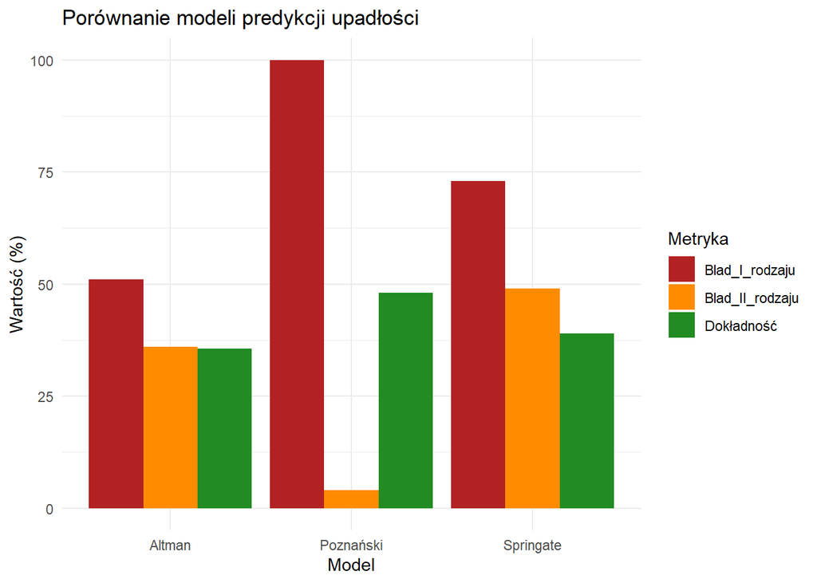

```r
# Dane do wykresu – pivot_longer
dane_wykres <- porownanie_modeli |>
  pivot_longer(cols = -Model, names_to = "Metryka", values_to = "Wartość")

ggplot(dane_wykres, aes(x = Model, y = Wartość * 100, fill = Metryka)) +
  geom_col(position = "dodge") +
  labs(title = "Porównanie modeli predykcji upadłości",
       y = "Wartość (%)",
       x = "Model",
       fill = "Metryka") +
  scale_fill_manual(values = c("Dokładność" = "forestgreen",
                               "Blad_I_rodzaju" = "firebrick",
                               "Blad_II_rodzaju" = "darkorange")) +
  theme_minimal()
```

Na podstawie tabeli porównawczej oraz wykresu można wywnioskować, iż analiza skuteczności trzech modeli predykcji upadłości wykazała, że żaden z nich nie osiągnął zadowalającej dokładności klasyfikacyjnej. Model Poznańskiego co prawda osiągnął najwyższą ogólną dokładność (48%), ale całkowicie zawiódł w rozpoznawaniu firm upadających – błąd I rodzaju wyniósł aż 100%, co oznacza, że wszystkie upadające firmy zostały błędnie zakwalifikowane jako przetrwałe. Model Springate’a również cechuje się niską dokładnością (39%) oraz wysokimi wskaźnikami obu rodzajów błędów, co świadczy o słabej zdolności rozróżniania między firmami zagrożonymi a stabilnymi. . Z kolei model Altmana osiągnął najniższą dokładność (35%) oraz dość znaczące błędy I i II rodzaju. Oznacza to, że przyjęte modele nie są dostosowane do specyfiki analizowanego zbioru danych (polskich firm). Wysokie błędy, szczególnie typu I, czynią je mało użytecznymi jako narzędzia predykcyjne w obecnej formie.

# 6 Stworzenie “polskiego” modelu Altmana

Celem niniejszego projektu jest stworzenie polskiego odpowiednika modelu Altmana, który służy do przewidywania bankructwa firm. Aby tego dokonać, wykorzystamy analizę dyskryminacyjną LDA (Linear Discriminant Analysis).

(LDA) to metoda statystyczna, która jest używana do klasyfikacji danych. Działa poprzez znajdowanie liniowych kombinacji cech, które najlepiej oddzielają różne klasy w danych. LDA stara się maksymalizować różnice między klasami, jednocześnie minimalizując zmienność wewnątrz klas. Jest to technika oparta na założeniu, że dane z różnych klas mają podobną macierz kowariancji i są rozkładane zgodnie z rozkładem normalnym.

Porównując nasze wyniki z oryginalnymi, będziemy mogli ocenić, jak dobrze LDA sprawdza się w kontekście przewidywania upadłości w polskich firmach, bazując na podobnym zbiorze zmiennych. Celem jest stworzenie modelu, który będzie odpowiedni do warunków rynkowych w Polsce i może zostać wykorzystany w praktyce do analizy ryzyka bankructwa.

## 6.1 Sprawdzenie założeń

Na początku projektu, przed przystąpieniem do budowy modelu, przeprowadzimy testy, aby sprawdzić, czy dane spełniają podstawowe założenia dla zastosowania LDA. Będziemy analizować, czy obserwacje są niezależne, czy klasy mają tę samą macierz kowariancji oraz czy zmienne w danych mają rozkład normalny.

### 6.1.1 Sprawdzenie normalności

**Show and hide code**

```r
normalnosc_x5 <- shapiro.test(sample(dane$x5, 5000))
normalnosc_x40 <- shapiro.test(sample(dane$x40, 5000))
normalnosc_x6  <- shapiro.test(sample(dane$x6, 5000))
normalnosc_x7  <- shapiro.test(sample(dane$x7, 5000))
normalnosc_x8  <- shapiro.test(sample(dane$x8, 5000))
normalnosc_x9  <- shapiro.test(sample(dane$x9, 5000))

p_values <- data.frame(
  zmienna = c("x40", "x6", "x7", "x8", "x9"),
  p_value = c(
    normalnosc_x40$p.value,
    normalnosc_x6$p.value,
    normalnosc_x7$p.value,
    normalnosc_x8$p.value,
    normalnosc_x9$p.value
  )
)

print(p_values)
```

```
  zmienna      p_value
1     x40 2.265804e-95
2      x6 1.440517e-95
3      x7 2.110989e-95
4      x8 1.163868e-89
5      x9 1.981577e-95
```

Wszystkie te zmienne nie spełniają założenia normalności, co może mieć znaczący wpływ na skuteczność LDA. To założenie zdecydowanie nie jest spełnione.

### 6.1.2 Sprawdzenie macierzy kowariancji

**Show and hide code**

```r
library(biotools)

# Wybieramy tylko zmienne x40, x6, x7, x8, x9
zmienne <- dane[, c("x40", "x6", "x7", "x8", "x9")]

# Dodajemy informację o klasie
klasy <- as.factor(dane[[65]])

# Box's M test
box_test <- boxM(zmienne, klasy)

# Wyniki
print(box_test)
```

```
    Box's M-test for Homogeneity of Covariance Matrices

data:  zmienne
Chi-Sq (approx.) = 9277.4, df = 15, p-value < 2.2e-16
```

Dane nie spełniają założenia homogeniczności macierzy kowariancji, co oznacza, że klasy różnią się pod względem rozproszenia i zależności między zmiennymi. LDA przez to może nie być optymalne oraz jest to kolejne założenie, które nie zostało spełnione.

### 6.1.3 Sprawdzennie niezależności

**Show and hide code**

```r
korelacje <- cor(dane[, c("x40", "x6", "x7", "x8", "x9")])

# Wyświetlanie macierzy korelacji
library(corrplot)
print(korelacje)
```

```
              x40          x6            x7           x8           x9
x40  1.0000000000 0.001161053 -0.0008058413  0.123136322 -0.001812995
x6   0.0011610530 1.000000000  0.2498623248  0.004782467  0.081817783
x7  -0.0008058413 0.249862325  1.0000000000 -0.018112814  0.365899330
x8   0.1231363221 0.004782467 -0.0181128135  1.000000000 -0.013204483
x9  -0.0018129945 0.081817783  0.3658993299 -0.013204483  1.000000000
```

**Show and hide code**

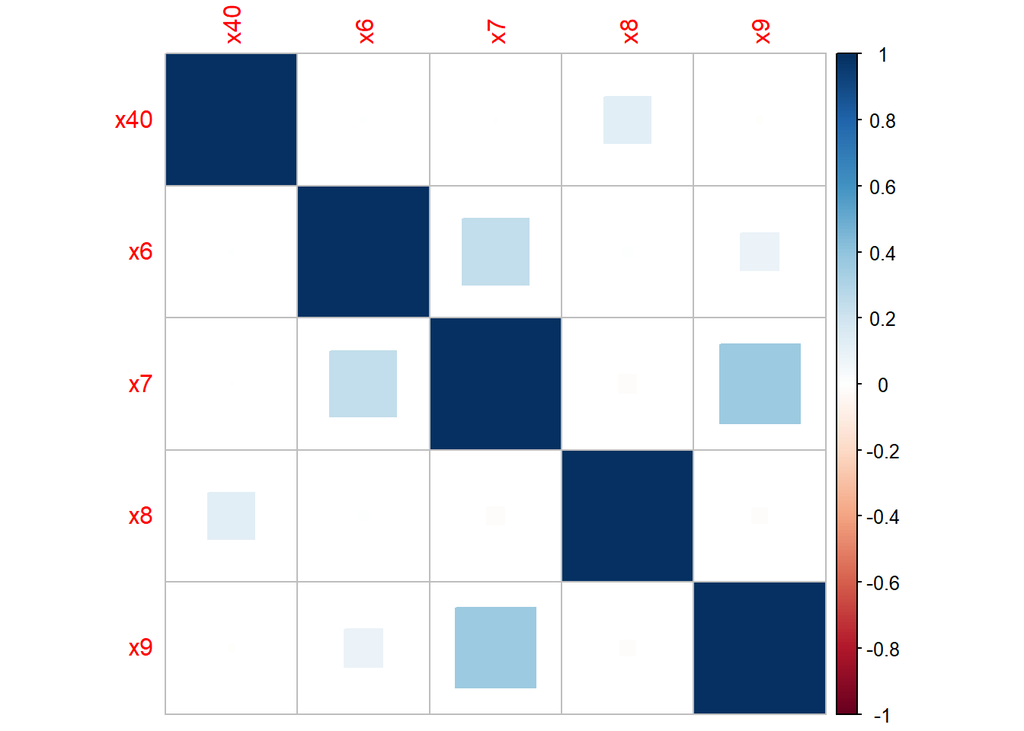

```r
corrplot(korelacje,"square")
```

Jak widać, zmienne nie są ze sobą wysoce skorelowane, najwyższa korlacja wynosi 0.37 między zmienną x7, a x9. Oznacza to, że nasze dane są od siebie niezależne.

Chociaż przeprowadzone testy wskazują, że nie wszystkie założenia wymagane do zastosowania analizy LDA zostały spełnione, postanowiliśmy kontynuować badanie, aby sprawdzić, czy metoda może mimo to dać interesujące i użyteczne wyniki.

## 6.2 LDA

**Show and hide code**

```r
dane_lda <- dane_wybrane

model_lda <- lda(x65 ~ x40 + x6 + x7 + x8 + x9, data = dane_lda)

#summary(model_lda)
model_lda
```

```
Call:
lda(x65 ~ x40 + x6 + x7 + x8 + x9, data = dane_lda)

Prior probabilities of groups:
  0   1
0.5 0.5

Group means:
     x40      x6     x7     x8     x9
0 0.5700  0.0436 0.1539 2.4530 1.8281
1 0.7134 -0.0046 0.0509 1.6926 2.2029

Coefficients of linear discriminants:
            LD1
x40  0.22449285
x6  -0.33164385
x7  -4.43754352
x8  -0.10108185
x9  -0.04460753
```

**Show and hide code**

```r
# Predykcja klas
pred_lda <- predict(model_lda)

# Dodajemy do danych
dane_lda$predykcja_lda <- as.numeric(pred_lda$class)

# Skuteczność (dokładność)
dokladnosc_lda <- mean(dane_lda$predykcja_lda == dane_lda$x65)
print(paste("Dokładność modelu LDA:", round(dokladnosc_lda * 100, 2), "%"))
```

```
[1] "Dokładność modelu LDA: 13 %"
```

**Show and hide code**

```r
model_lda$scaling #wagi wpspółzmiennych
```

```
            LD1
x40  0.22449285
x6  -0.33164385
x7  -4.43754352
x8  -0.10108185
x9  -0.04460753
```

**Show and hide code**

```r
library(ggplot2)
```

Model LDA, dla “polskich” danych pokazuje interesujące wyniki. Mimo że założenia dotyczące normalności danych i homogeniczności kowariancji nie zostały w pełni spełnione, model został uruchomiony, a uzyskane wyniki wskazują na stosunkowo niską dokładność predykcji, wynoszącą zaledwie 13%. Mimo to, współczynniki dyskryminantów (waga zmiennych w modelu) są nadal użyteczne, ponieważ wskazują, które zmienne (x40, x6, x7, x8, x9) mają największy wpływ na różnicowanie klas.

## 6.3 Poszerzone badanie

Postanowliśmy wysunąć czynnik losowy przed nawias i powtórzyć badanie 100 razy, żeby sprawdzić, czy da porównywalne wyniki.

**Show and hide code**

```r
library(MASS)     # lda()
library(dplyr)    # bind_rows
library(tibble)   # tibble()

# Puste listy na wyniki
zbiorcze_dane <- list()
dokladnosci <- numeric()
zbiorcze_predykcje <- list()
zbiorcze_scaling <- list()  # tutaj będą współczynniki LDA

for (i in 1:100) {
  set.seed(i)

  firmy_upadle <- dane %>%
    filter(x65 == 0) %>%
    sample_n(100)

  firmy_przetrwaly <- dane %>%
    filter(x65 == 1) %>%
    sample_n(100)

  dane_lda <- bind_rows(firmy_upadle, firmy_przetrwaly)

  model_lda <- lda(x65 ~ x40 + x6 + x7 + x8 + x9, data = dane_lda)
  pred_lda <- predict(model_lda)

  # Dodanie predykcji do danych
  dane_lda$predykcja_lda <- as.numeric(pred_lda$class)
  dane_lda$iteracja <- i

  # Obliczanie dokładności
  dokladnosc_lda <- mean(dane_lda$predykcja_lda == dane_lda$x65)

  # Zbieranie wyników
  zbiorcze_dane[[i]] <- dane_lda
  zbiorcze_predykcje[[i]] <- data.frame(iteracja = i, predykcja = pred_lda$class)
  dokladnosci[i] <- dokladnosc_lda

  # Dodanie scaling (dobranych współczynników)
  scaling_df <- as.data.frame(model_lda$scaling)
  scaling_df$zmienna <- rownames(scaling_df)
  scaling_df$iteracja <- i
  rownames(scaling_df) <- NULL
  zbiorcze_scaling[[i]] <- scaling_df
}

# Sklejanie zbiorczych wyników
tabela_dane <- bind_rows(zbiorcze_dane)
tabela_predykcje <- bind_rows(zbiorcze_predykcje)
tabela_dokladnosci <- tibble(iteracja = 1:100, dokladnosc = dokladnosci)
tabela_scaling <- bind_rows(zbiorcze_scaling)


print(tabela_dokladnosci)
```

```
# A tibble: 100 × 2
   iteracja dokladnosc
      <int>      <dbl>
 1        1      0.16
 2        2      0.17
 3        3      0.155
 4        4      0.1
 5        5      0.155
 6        6      0.14
 7        7      0.275
 8        8      0.155
 9        9      0.145
10       10      0.115
# ℹ 90 more rows
```

**Show and hide code**

```r
library(dplyr)
print(paste("Średnia dokładność modelu polskiego wynosi:", round(mean(dokladnosci * 100), 2), "%"))
```

```
[1] "Średnia dokładność modelu polskiego wynosi: 16.09 %"
```

**Show and hide code**

```r
colnames(tabela_scaling)[1:3] <- c("LD1", "zmienna", "iteracja")

# Zamiana na format szeroki
tabela_scaling_szeroka <- tabela_scaling %>%
  pivot_wider(
    names_from = zmienna,
    values_from = LD1
  ) %>%
  arrange(iteracja)

# Podgląd końcowej tabeli
print(tabela_scaling_szeroka)
```

```
# A tibble: 100 × 6
   iteracja      x40     x6     x7        x8      x9
      <int>    <dbl>  <dbl>  <dbl>     <dbl>   <dbl>
 1        1  0.105   -1.89  -3.07  -0.0258   -0.0413
 2        2  0.111   -1.79  -4.08  -0.0674   -0.0394
 3        3  0.0224  -1.19  -4.19  -0.000718  0.137
 4        4  0.452   -1.81   0.689 -0.287    -0.0973
 5        5  0.0605  -2.52  -2.39  -0.0278   -0.0128
 6        6  0.170    0.525 -3.46  -0.191    -0.151
 7        7  0.0592   0.299 -2.00  -0.0281    0.648
 8        8 -0.149   -2.62  -3.57   0.0431    0.213
 9        9 -0.00209  0.682 -4.46  -0.0819    0.254
10       10  0.402   -2.73  -2.37  -0.263     0.0250
# ℹ 90 more rows
```

**Show and hide code**

```r
srednie_scaling <- tabela_scaling_szeroka %>%
  summarise(across(everything(), mean))  # Obliczamy średnie dla wszystkich kolumn

# Przekształcamy do formatu długiego
srednie_scaling_long <- srednie_scaling %>%
  pivot_longer(
    cols = everything(),
    names_to = "zmienna",
    values_to = "srednia_wartosc"
  )

# ✅ Podgląd wyników
print(srednie_scaling_long)
```

```
# A tibble: 6 × 2
  zmienna  srednia_wartosc
  <chr>              <dbl>
1 iteracja         50.5
2 x40               0.125
3 x6               -0.846
4 x7               -3.00
5 x8               -0.0900
6 x9                0.0862
```

**Show and hide code**

```r
# Tworzymy dane do porównania
dane_porownanie <- data.frame(
  Zmienna = c("x40", "x6", "x7", "x8", "x9"),
  Nasz_model = c(0.125, -0.846, -3.00, -0.0900, 0.0862),
  Altman_model = c(1.2, 1.4, 3.3, 0.6, 0.99)
)

# Wyświetlamy tabelę porównawczą
print(dane_porownanie)
```

```
  Zmienna Nasz_model Altman_model
1     x40     0.1250         1.20
2      x6    -0.8460         1.40
3      x7    -3.0000         3.30
4      x8    -0.0900         0.60
5      x9     0.0862         0.99
```

## 6.4 Porównanie wartości zmiennych w “polskim” modelu LDA oraz w modelu Altmana:

Podobnie waga zmiennej x6, odpowiadającej zyskowi zatrzymanemu w stosunku do aktywów ogółem, w naszym modelu wynosi -0.8460, podczas gdy w modelu Altmana X6 ma wagę 1.40. Odmienny kierunek korelacji sugeruje, że zysk zatrzymany może być niechcianą wartością dla polskich firm. Zmienna x7, reprezentująca stosunek zysku przed spłatą odsetek i podatkiem do aktywów ogółem, jest istotnie obniżona w naszym modelu (-3.0000), w przeciwieństwie do modelu Altmana, gdzie ma wagę 3.30, co jest bardzo zaskakujące. Nasz model sugeruje odwrotny skutek tej zmiennej na szansę ogłoszenia upadłości przez firmę.

Wagi dla zmiennych x8 i x9 również wykazują różnice w obu modelach: w naszym modelu zmienne te mają wagi bliskie zeru (-0.0900 dla x8 oraz 0.0862 dla x9), podczas gdy w modelu Altmana X8 i X9 mają przypisane wagi 0.60 i 0.99, co może wskazywać na większą wagę tych zmiennych w klasyfikacji bankructwa w oryginalnym modelu Altmana.

Zmiany są bardzo istotne i jednym z możliwych wytłumaczeń jest to, że w pierwszej kolejności nie powinniśmy stosować LDA w naszym modelu, gdyż założenia nie są spełnione. Wpływa to znacząco na dokładność modelu, która jest bardzo niska. Dosłownie lepszym wyborem byłoby zgadywać i mielibyśmy szansę na porównywalne lub lepsze wyniki.